# Penguin

MW

8/2/2020

# 1. Exploration Data Analysis

The penguin dataset has 8 variables consist of 3 character variables and 5 numeric variables (including year variable). There are 3 species (Adelie, Gentoo, Chinstrap) for each sex (male and female), 3 islands (Torgersen, Biscoe, Dream). Observation in the penguin dataset was took place in 2007, 2008, and 2009.

There are 344 with the following missing observations:

| Column Name | No of missing observation |
| --- | --- |
| bill_length_mm | 2 |
| bill_depth_mm | 2 |
| flipper_length_mm | 2 |
| body_mass_g | 2 |
| sex | 11 |

11 observations were missing for sex variable. Summary of missing observation in sex variable is tabulized as follow:

| Species | 2007 | 2008 | 2009 |
| --- | --- | --- | --- |
| Adelie | 6 | 0 | 0 |
| Gentoo | 1 | 1 | 3 |

Imputation on missing data for sex variable will be done before modelling.

According to bar plot below, penguins dataset contains balance of observation number between female and male, but imbalance exist within species.

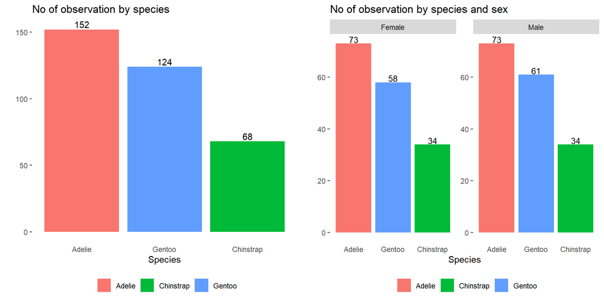

## 1.1 Data Distribution

Gentoo’s bill depth, body mass, and flipper length are vary significantly compare to other species. Adelie can be distinguished clearly compare to other species from its bill length.

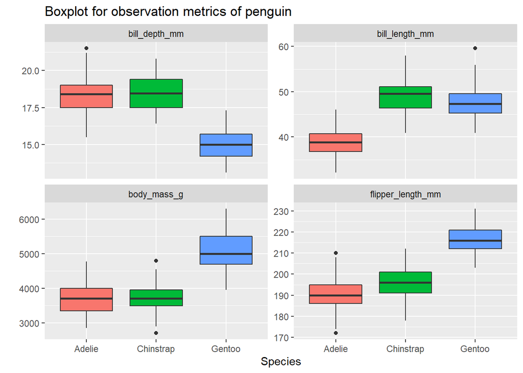

From the boxplot and radar charts below, metric by sex shown that male has higher value than female.

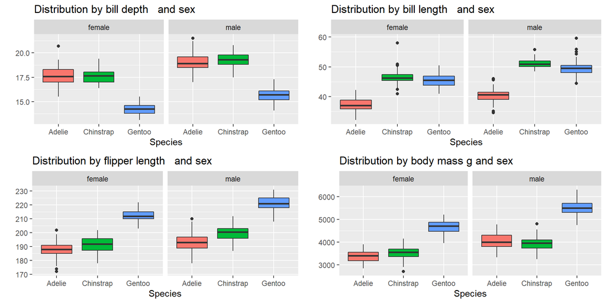

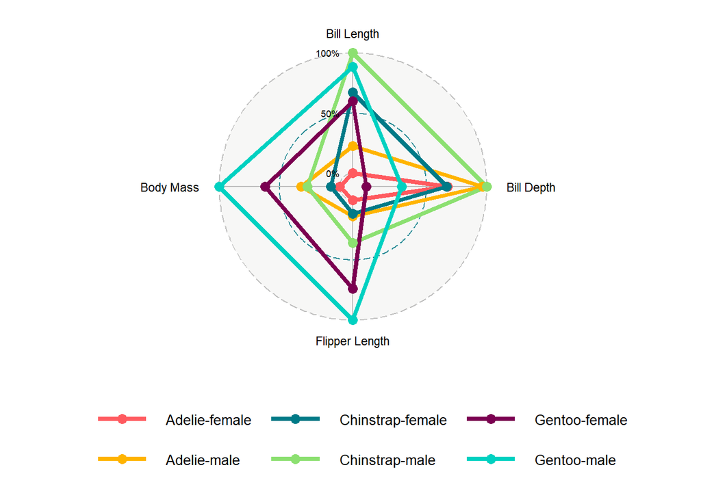

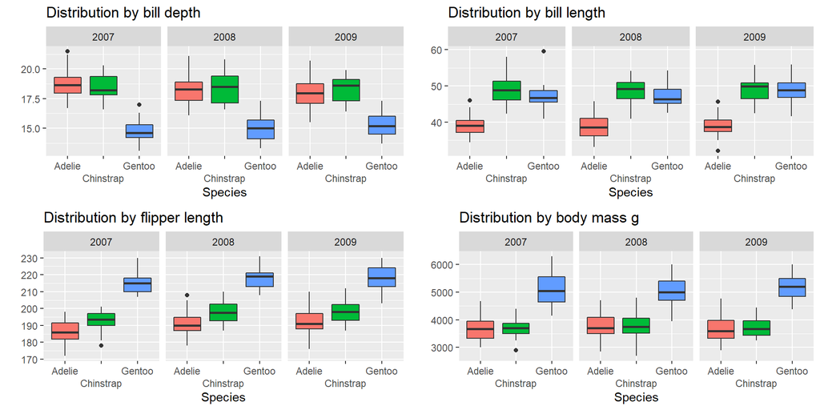

Metric distribution appears follow normal distribution.

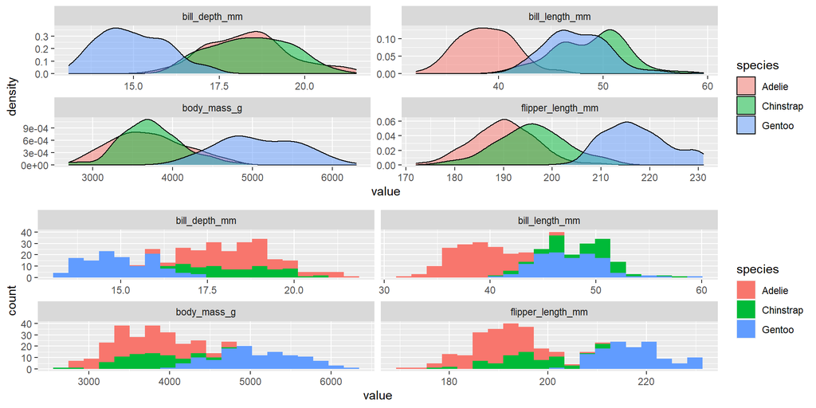

Below bar plot shown number of observation by island and species. Adelie lives in the three islands, but Gentoo and Chinstrap lives in Biscoe island and Dream island, respectively.

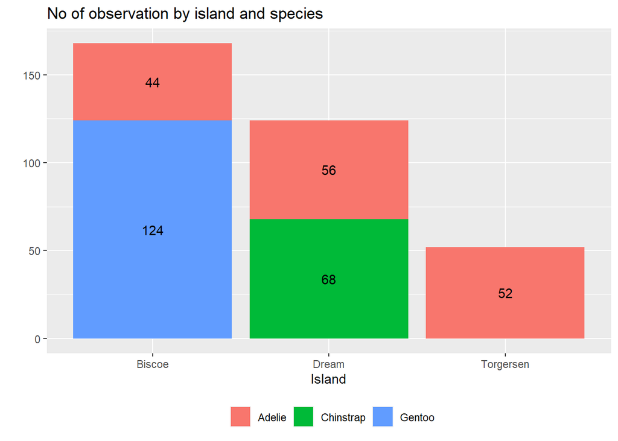

[figure not shown]

## Models to predict species